# PS07

Srishti Dubey

12/2/2021

# 1 Titanic: What Happened During Her Last Hours?

## 1.1 Titanic Data

### 1.1.1

```r
titanic_df <- read.csv("../titanic.csv.bz2")
head(titanic_df,2)
```

```
##   pclass survived                           name    sex     age sibsp parch
## 1      1        1  Allen, Miss. Elisabeth Walton female 29.0000     0     0
## 2      1        1 Allison, Master. Hudson Trevor   male  0.9167     1     2
##   ticket     fare   cabin embarked boat body                       home.dest
## 1  24160 211.3375      B5        S    2   NA                    St Louis, MO
## 2 113781 151.5500 C22 C26        S   11   NA Montreal, PQ / Chesterville, ON
```

```r
nrow(titanic_df)
```

```
## [1] 1309
```

### 1.1.2

```r
any(is.na(titanic_df))
```

```
## [1] TRUE
```

```r
summary(titanic_df)
```

```
##      pclass         survived         name               sex
##  Min.   :1.000   Min.   :0.000   Length:1309        Length:1309
##  1st Qu.:2.000   1st Qu.:0.000   Class :character   Class :character
##  Median :3.000   Median :0.000   Mode  :character   Mode  :character
##  Mean   :2.295   Mean   :0.382
##  3rd Qu.:3.000   3rd Qu.:1.000
##  Max.   :3.000   Max.   :1.000
##
##       age              sibsp            parch          ticket
##  Min.   : 0.1667   Min.   :0.0000   Min.   :0.000   Length:1309
##  1st Qu.:21.0000   1st Qu.:0.0000   1st Qu.:0.000   Class :character
##  Median :28.0000   Median :0.0000   Median :0.000   Mode  :character
##  Mean   :29.8811   Mean   :0.4989   Mean   :0.385
##  3rd Qu.:39.0000   3rd Qu.:1.0000   3rd Qu.:0.000
##  Max.   :80.0000   Max.   :8.0000   Max.   :9.000
##  NA's   :263
##       fare            cabin             embarked             boat
##  Min.   :  0.000   Length:1309        Length:1309        Length:1309
##  1st Qu.:  7.896   Class :character   Class :character   Class :character
##  Median : 14.454   Mode  :character   Mode  :character   Mode  :character
##  Mean   : 33.295
##  3rd Qu.: 31.275
##  Max.   :512.329
##  NA's   :1
##       body        home.dest
##  Min.   :  1.0   Length:1309
##  1st Qu.: 72.0   Class :character
##  Median :155.0   Mode  :character
##  Mean   :160.8
##  3rd Qu.:256.0
##  Max.   :328.0
##  NA's   :1188
```

Amongst variables: survived, pclass, sex variables do not have missing values. ‘age’ variable has 263 missing values. ‘body’ variable has a huge number of missing values: 1188. ‘fare’ has 1 missing value.

### 1.1.3

I see the following implausible values: We can see that min fare is 0, which means either some passengers got a ticket for free or there is some discrepancy in records. The max fare is $ 512 which is very high when compared to mean or median.

## 1.2 Logistic Regression

### 1.2.1

Based on the survivors accounts, pclass, sex, age, survived are the most important variables to describe survival. As per the survivor accounts, women and children had higher chances of survival especially women and children from the upper class. Also, pclass plays a major role in survival as 1st class passengers were given preference while evacuating.

### 1.2.2

```r
titanic_df['child'] <- 0
names(titanic_df)
```

```
##  [1] "pclass"    "survived"  "name"      "sex"       "age"       "sibsp"
##  [7] "parch"     "ticket"    "fare"      "cabin"     "embarked"  "boat"
## [13] "body"      "home.dest" "child"
```

```r
titanic_df$child <- ifelse(titanic_df$age < 14, 1, 0)
head(titanic_df,4)
```

```
##   pclass survived                                 name    sex     age sibsp
## 1      1        1        Allen, Miss. Elisabeth Walton female 29.0000     0
## 2      1        1       Allison, Master. Hudson Trevor   male  0.9167     1
## 3      1        0         Allison, Miss. Helen Loraine female  2.0000     1
## 4      1        0 Allison, Mr. Hudson Joshua Creighton   male 30.0000     1
##   parch ticket     fare   cabin embarked boat body
## 1     0  24160 211.3375      B5        S    2   NA
## 2     2 113781 151.5500 C22 C26        S   11   NA
## 3     2 113781 151.5500 C22 C26        S        NA
## 4     2 113781 151.5500 C22 C26        S       135
##                         home.dest child
## 1                    St Louis, MO     0
## 2 Montreal, PQ / Chesterville, ON     1
## 3 Montreal, PQ / Chesterville, ON     1
## 4 Montreal, PQ / Chesterville, ON     0
```

### 1.2.3

We have to treat pclass as categorical variable as we need to group the values in pclass in terms of people being which class passengers. In pclass, passengers belong to classes 1,2,3 and no mathematical operations can be performed to derive insights.

```r
titanic_df$pclass <- as.factor(titanic_df$pclass)
head(titanic_df,3)
```

```
##   pclass survived                           name    sex     age sibsp parch
## 1      1        1  Allen, Miss. Elisabeth Walton female 29.0000     0     0
## 2      1        1 Allison, Master. Hudson Trevor   male  0.9167     1     2
## 3      1        0   Allison, Miss. Helen Loraine female  2.0000     1     2
##   ticket     fare   cabin embarked boat body                       home.dest
## 1  24160 211.3375      B5        S    2   NA                    St Louis, MO
## 2 113781 151.5500 C22 C26        S   11   NA Montreal, PQ / Chesterville, ON
## 3 113781 151.5500 C22 C26        S        NA Montreal, PQ / Chesterville, ON
##   child
## 1     0
## 2     1
## 3     1
```

### 1.2.4

```r
m <- glm(survived ~ pclass + sex + age + factor(child), data=titanic_df, family=binomial())
library(margins)
summary(margins(m))
```

```
##   factor     AME     SE        z      p   lower   upper
##      age -0.0040 0.0011  -3.5860 0.0003 -0.0062 -0.0018
##   child1  0.0914 0.0512   1.7837 0.0745 -0.0090  0.1919
##  pclass2 -0.2168 0.0383  -5.6626 0.0000 -0.2919 -0.1418
##  pclass3 -0.3736 0.0351 -10.6365 0.0000 -0.4425 -0.3048
##  sexmale -0.4870 0.0281 -17.3541 0.0000 -0.5420 -0.4320
```

### 1.2.5

Interpretations:-

Sex:- As compared to females, males has 48.70 pct pt lesser chances of survival in the titanic, considering all variables remain constant. This shows that women had larger chances of survival during the titanic disaster.

Age:- We can see from the results, with every 1 year increase in age, the chances of survival reduce by 0.40 pct pt

pclass:- Considering the passenger class, pclass2 has 21.68 pct pt lesser chance of survival than pclass 1, and pclass3 has 37.36 pct pt lesser chance of survival than pclass1

This lets us to the conclusion that as per the maritime safety protocols of that time, women and children were given preference while evacuating. Similarly, 1st class passengers were given priority while evacuating and thus, these groups had higher chances of survival.

### 1.2.6

```r
library(tidyverse)
titanic_df <- titanic_df %>%
  mutate(young_man=as.integer(sex=='male' & age <= 35 & age >= 18))

head(titanic_df)
```

```
##   pclass survived                                            name    sex
## 1      1        1                   Allen, Miss. Elisabeth Walton female
## 2      1        1                  Allison, Master. Hudson Trevor   male
## 3      1        0                    Allison, Miss. Helen Loraine female
## 4      1        0            Allison, Mr. Hudson Joshua Creighton   male
## 5      1        0 Allison, Mrs. Hudson J C (Bessie Waldo Daniels) female
## 6      1        1                             Anderson, Mr. Harry   male
##       age sibsp parch ticket     fare   cabin embarked boat body
## 1 29.0000     0     0  24160 211.3375      B5        S    2   NA
## 2  0.9167     1     2 113781 151.5500 C22 C26        S   11   NA
## 3  2.0000     1     2 113781 151.5500 C22 C26        S        NA
## 4 30.0000     1     2 113781 151.5500 C22 C26        S       135
## 5 25.0000     1     2 113781 151.5500 C22 C26        S        NA
## 6 48.0000     0     0  19952  26.5500     E12        S    3   NA
##                         home.dest child young_man
## 1                    St Louis, MO     0         0
## 2 Montreal, PQ / Chesterville, ON     1         0
## 3 Montreal, PQ / Chesterville, ON     1         0
## 4 Montreal, PQ / Chesterville, ON     0         1
## 5 Montreal, PQ / Chesterville, ON     0         0
## 6                    New York, NY     0         0
```

```r
m1 <- glm(survived ~ age + sex + factor(child) + pclass + young_man, data = titanic_df, family = binomial())

summary(margins(m1))
```

```
##     factor     AME     SE        z      p   lower   upper
##        age -0.0036 0.0013  -2.7956 0.0052 -0.0060 -0.0011
##     child1  0.1172 0.0622   1.8836 0.0596 -0.0048  0.2391
##    pclass2 -0.2205 0.0386  -5.7158 0.0000 -0.2960 -0.1449
##    pclass3 -0.3764 0.0353 -10.6531 0.0000 -0.4457 -0.3072
##    sexmale -0.5071 0.0375 -13.5299 0.0000 -0.5806 -0.4337
##  young_man  0.0300 0.0388   0.7750 0.4383 -0.0459  0.1060
```

## 2 Predict AirBnB Price

### 2.1

```r
airbnb_df <- read.csv("../airbnb-vancouver-bc-listings.csv.bz2")
dim(airbnb_df)
```

```
## [1] 4448   74
```

```r
any(is.na(airbnb_df))
```

```
## [1] TRUE
```

Selecting only relevant variables:

```r
airbnb_df <- airbnb_df %>%
  select(price, bedrooms, room_type, accommodates)
head(airbnb_df)
```

```
##     price bedrooms       room_type accommodates
## 1 $158.00        2 Entire home/apt            5
## 2 $150.00       NA Entire home/apt            4
## 3  $85.00        1 Entire home/apt            2
## 4 $149.00        1 Entire home/apt            2
## 5 $150.00        1 Entire home/apt            4
## 6 $350.00        2 Entire home/apt            4
```

```r
summary(airbnb_df)
```

```
##     price              bedrooms       room_type          accommodates
##  Length:4448        Min.   : 1.000   Length:4448        Min.   : 1.000
##  Class :character   1st Qu.: 1.000   Class :character   1st Qu.: 2.000
##  Mode  :character   Median : 1.000   Mode  :character   Median : 3.000
##                     Mean   : 1.601                      Mean   : 3.427
##                     3rd Qu.: 2.000                      3rd Qu.: 4.000
##                     Max.   :13.000                      Max.   :16.000
##                     NA's   :312
```

Only variable bedroom has 312 missing values

### 2.2 Basic Data Cleaning

#### a convert price to numeric

```r
airbnb_df$price <- gsub("[$]|[,]", "", airbnb_df$price)
airbnb_df$price <- as.numeric(airbnb_df$price)
head(airbnb_df)
```

```
##   price bedrooms       room_type accommodates
## 1   158        2 Entire home/apt            5
## 2   150       NA Entire home/apt            4
## 3    85        1 Entire home/apt            2
## 4   149        1 Entire home/apt            2
## 5   150        1 Entire home/apt            4
## 6   350        2 Entire home/apt            4
```

#### b Remove entries with missing or invalid price, bedrooms, and other variables you need

```r
airbnb_df %>% filter(is.na(bedrooms)) %>% head()
```

```
##   price bedrooms       room_type accommodates
## 1   150       NA Entire home/apt            4
## 2   240       NA Entire home/apt            2
## 3   102       NA Entire home/apt            2
## 4  1950       NA Entire home/apt            2
## 5   120       NA Entire home/apt            3
## 6   230       NA Entire home/apt            2
```

```r
mean(airbnb_df$bedrooms)
```

```
## [1] NA
```

```r
median(airbnb_df$bedrooms)
```

```
## [1] NA
```

```r
airbnb_df$bedrooms[is.na(airbnb_df$bedrooms)] <- 0
head(airbnb_df)
```

```
##   price bedrooms       room_type accommodates
## 1   158        2 Entire home/apt            5
## 2   150        0 Entire home/apt            4
## 3    85        1 Entire home/apt            2
## 4   149        1 Entire home/apt            2
## 5   150        1 Entire home/apt            4
## 6   350        2 Entire home/apt            4
```

We cannot with data set that has NA as number of bedrooms, hence we substitute NA with 0 bedrooms. Also, if we see the link to data set, the apartments with NA bedrooms are studio apartments; as studio apartments usually have 0 bedrooms. Hence, we replace NA value with 0 bedrooms.

### 2.3

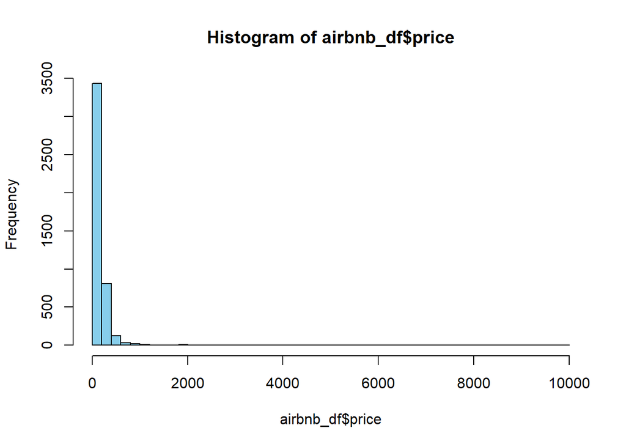

```r
hist(airbnb_df$price, breaks = 40, col="skyblue")
```

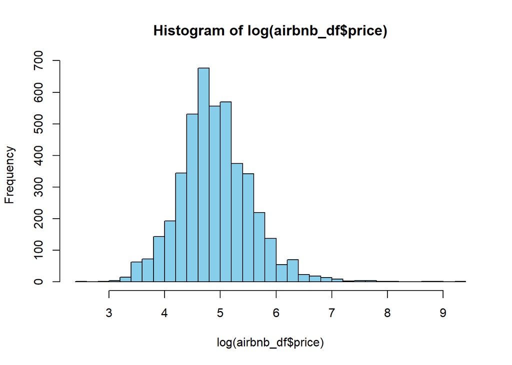

```r
hist(log(airbnb_df$price), breaks = 40, col="skyblue")
```

After we logged the price distribution, we see that the distribution does seem quite normal. So we need to perform log transformation on the Price variable.

### 2.4

```r
airbnb_df$bedroom_category <-
  cut(airbnb_df$bedrooms,
                breaks=c(0, 1, 2, 3, Inf),
                labels=c("0", "1", "2", "3+"),
                include.lowest=TRUE,
                right=FALSE
                )
head(airbnb_df)
```

```
##   price bedrooms       room_type accommodates bedroom_category
## 1   158        2 Entire home/apt            5                2
## 2   150        0 Entire home/apt            4                0
## 3    85        1 Entire home/apt            2                1
## 4   149        1 Entire home/apt            2                1
## 5   150        1 Entire home/apt            4                1
## 6   350        2 Entire home/apt            4                2
```

### 2.5

Trying linear regression initially without log(price):

```r
m_airbnb_df <- lm(price ~ bedroom_category, data =  airbnb_df)

summary(m_airbnb_df)
```

```
##
## Call:
## lm(formula = price ~ bedroom_category, data = airbnb_df)
##
## Residuals:
##    Min     1Q Median     3Q    Max
## -365.6  -63.7  -27.5   23.5 9872.5
##
## Coefficients:
##                    Estimate Std. Error t value Pr(>|t|)
## (Intercept)          142.75      15.71   9.087  < 2e-16 ***
## bedroom_category1    -16.20      16.68  -0.971  0.33164
## bedroom_category2     51.32      17.71   2.897  0.00378 **
## bedroom_category3+   247.84      19.69  12.585  < 2e-16 ***
## ---
## Signif. codes:  0 '***' 0.001 '**' 0.01 '*' 0.05 '.' 0.1 ' ' 1
##
## Residual standard error: 277.5 on 4444 degrees of freedom
## Multiple R-squared:  0.08508,    Adjusted R-squared:  0.08446
## F-statistic: 137.7 on 3 and 4444 DF,  p-value: < 2.2e-16
```

Without logged price distribution, R-squared value: 0.08508.

Here apartments with 0 bedrooms is the reference category, the average price for a 0 bedroom apartment is $ 142.75. 1 bedroom apartments are lesser in price than 0 bedroom apartments/studio apartments by $ 16.20. Also 1 bedroom apartments are not statistically significant. As the number of bedrooms increases to 2, the average price of apartment increases by $ 51.32 when compared to a 0 bedroom apartment. As the number of bedrooms increases to 3, the average price of apartment increases by $ 247.84 when compared to a 0 bedroom apartment.

As per earlier analysis log of price distribution gives us normalized results, hence estimating a linear regression model with log of the price variable:

```r
m1_airbnb_df <- lm(log(price) ~ bedroom_category, data =  airbnb_df)

summary(m1_airbnb_df)
```

```
##
## Call:
## lm(formula = log(price) ~ bedroom_category, data = airbnb_df)
##
## Residuals:
##     Min      1Q  Median      3Q     Max
## -2.4411 -0.3292 -0.0415  0.3315  4.5636
##
## Coefficients:
##                    Estimate Std. Error t value Pr(>|t|)
## (Intercept)         4.72903    0.03085 153.281   <2e-16 ***
## bedroom_category1  -0.08235    0.03277  -2.513    0.012 *
## bedroom_category2   0.42656    0.03479  12.262   <2e-16 ***
## bedroom_category3+  0.93094    0.03868  24.071   <2e-16 ***
## ---
## Signif. codes:  0 '***' 0.001 '**' 0.01 '*' 0.05 '.' 0.1 ' ' 1
##
## Residual standard error: 0.545 on 4444 degrees of freedom
## Multiple R-squared:  0.2964, Adjusted R-squared:  0.2959
## F-statistic: 623.9 on 3 and 4444 DF,  p-value: < 2.2e-16
```

With logged price distribution, R-squared value: 0.2964.

This shows us that the logged price distribution gives us a better linear regression model, as R squared value is higher for the logged price model, since, the closer the R squared value to 1, better is the model.

### 2.6

```r
table(airbnb_df$room_type)
```

```
##
## Entire home/apt      Hotel room    Private room     Shared room
##            3582               4             854               8
```

```r
table(airbnb_df$accommodates)
```

```
##
##    1    2    3    4    5    6    7    8    9   10   11   12   13   14   15   16
##  288 1699  462 1108  247  412   61  101    8   27    5   14    3    7    1    5
```

### 2.7

Convert the room type into 3 categories: Entire home/apt, Private room, Other:-

```r
airbnb_df$room_type[airbnb_df$room_type == 'Hotel room' | airbnb_df$room_type == 'Shared room']<- "Other"
head(airbnb_df)
```

```
##   price bedrooms       room_type accommodates bedroom_category
## 1   158        2 Entire home/apt            5                2
## 2   150        0 Entire home/apt            4                0
## 3    85        1 Entire home/apt            2                1
## 4   149        1 Entire home/apt            2                1
## 5   150        1 Entire home/apt            4                1
## 6   350        2 Entire home/apt            4                2
```

```r
table(airbnb_df$room_type)
```

```
##
## Entire home/apt           Other    Private room
##            3582              12             854
```

Convert accommodates into 3 categories: “1”, “2”, “3 or more” :-

```r
airbnb_df <- airbnb_df %>%
  mutate(accommodates =
  cut(accommodates,
                breaks=c(0, 1, 2, 3, Inf),
                labels=c("0", "1", "2", "3 or more"),
                include.lowest=TRUE,
                right=FALSE
                ))
head(airbnb_df)
```

```
##   price bedrooms       room_type accommodates bedroom_category
## 1   158        2 Entire home/apt    3 or more                2
## 2   150        0 Entire home/apt    3 or more                0
## 3    85        1 Entire home/apt            2                1
## 4   149        1 Entire home/apt            2                1
## 5   150        1 Entire home/apt    3 or more                1
## 6   350        2 Entire home/apt    3 or more                2
```

```r
table(airbnb_df$accommodates)
```

```
##
##         0         1         2 3 or more
##         0       288      1699      2461
```

### 2.8

```r
m2_airbnb_df <- lm(log(price) ~ bedroom_category + room_type + accommodates, data =  airbnb_df)

summary(m2_airbnb_df)
```

```
##
## Call:
## lm(formula = log(price) ~ bedroom_category + room_type + accommodates,
##     data = airbnb_df)
##
## Residuals:
##     Min      1Q  Median      3Q     Max
## -2.4534 -0.3134 -0.0555  0.2572  4.8504
##
## Coefficients:
##                        Estimate Std. Error t value Pr(>|t|)
## (Intercept)            4.441962   0.043801 101.412  < 2e-16 ***
## bedroom_category1      0.005536   0.030714   0.180    0.857
## bedroom_category2      0.274670   0.035704   7.693 1.76e-14 ***
## bedroom_category3+     0.766063   0.039203  19.541  < 2e-16 ***
## room_typeOther        -0.118880   0.145918  -0.815    0.415
## room_typePrivate room -0.396423   0.023202 -17.085  < 2e-16 ***
## accommodates2          0.308814   0.034615   8.921  < 2e-16 ***
## accommodates3 or more  0.464217   0.038710  11.992  < 2e-16 ***
## ---
## Signif. codes:  0 '***' 0.001 '**' 0.01 '*' 0.05 '.' 0.1 ' ' 1
##
## Residual standard error: 0.4999 on 4440 degrees of freedom
## Multiple R-squared:  0.4085, Adjusted R-squared:  0.4076
## F-statistic: 438.1 on 7 and 4440 DF,  p-value: < 2.2e-16
```

In this linear regression model, accommodates1, entire home/apartment and bedroom 0, meaning, airbnb homes accommodated by 1 person with 0 bedrooms and room types as ‘entire home/apartment’ is the reference category and the R squared value is 0.4085. bedroom_category1 and room_typeOther are statistically insignificant.

Houses with more number of bedrooms have higher log price when compared to 0 bed apartments, considering all other variables as constant.

People prefer entire home/apartment for themselves rather than just a private room, shared room or hotel room, this may be the reason why the log price of ‘Private room’ or ‘Other’ room is lower in comparison to ‘entire home/apartment’

Houses that accommodate more number of people have higher log price when compared to apartments that accommodate 1 person, considering all other variables as constant

### 2.9

Room Type ‘Other’ being statistically insignificant means that the presence or absence of this variable does not have any significant impact on the results of the model, while considering impacts of all other significant variables of the model. Room Type Other comprises of data from room types: Hotel Room & Shared Room As we can see in 2.6, Other room_type has total number of 12 observations. Meaning it has very less values to predict the effect on the linear regression model. This may be the reason why, Room Type ‘Other’ is statistically insignificant, it also has high p-value and low t-value. Its impact on other variables cannot be clearly defined.

### 2.10

```r
predicted_log_price <- predict(m2_airbnb_df)
head(predicted_log_price)
```

```
##        1        2        3        4        5        6
## 5.180849 4.906179 4.756312 4.756312 4.911715 5.180849
```

### 2.11

```r
rmse <- sqrt(mean((predicted_log_price - log(airbnb_df$price))^2))
rmse
```

```
## [1] 0.4994184
```

RMSE : 0.4994184

### 2.12

```r
newdata <- data.frame(bedroom_category = "2", room_type="Entire home/apt", accommodates = "3 or more")

estimated_logprice <- predict(m2_airbnb_df, newdata = newdata)
estimated_logprice
```

```
##        1
## 5.180849
```

The predicted log price for a 2-bedroom apartment that accommodates 4 (i.e. a full 2BR apartment), using our above model is 5.1808489

Time spent on this PS: 14 hrs